# BXD reproducibility with mm10: visualization

Nastassia Gobet, Maxime Jan

1 February 2019

# Plan

- lower-level steps:
  - eQTL detection with fastQTL (check Fig2c)
  - differential gene expression (check Fig4c) with R script: limma_RNA.R
  - phQTL detection with R/qtl (4 examples)
  - mQTL detection with R/qtl (2 examples)
- higher-layer:
  - gene prioritization for the 4 examples
  1. *Wrn* for delta1-power gain in NREM sleep
  2. *Kif16b* for delta2-power gain in NREM sleep
  3. *Cyp4a32* for thetha frequency in REM sleep
  4. *Acott11* for compensation for NREM sleep time lost
  - hiveplots vizualisation

# Analysis

## eQTL detection

### Software

The eQTL detection was performed with fastQTL version 2.184 using default parameters, except for:

- used the beta distribution approximation estimated from 1000 permutations to calculate adjusted p-values (–permute 1000, no default)
- tests association for a molecular phenotype only for variants that are 2 Mb above or below the transcription start site of the gene coding for the phenotype (–window 2e6, default is 1e6)
- chose to use seed one to help reproducibility of permutations (–seed 1, no default)
- Ndufa12 had to be removed to avoid an error in FastQTL during beta parameter estimation for Cortex.SD. Same with Mettl25 for LNSD and LSD. The reason of this error is not completely understood. The fastQTL was run separately for them on not log CPM data, and the output was added before the qvalues calculation.

### Visualization

Trying to reproduce the venn diagram (Figure 2c) with the newly calculated data.

```r
#loading needed library
##install.packages("VennDiagram")
library(VennDiagram)
# load files with qvalues of genes for cis-eQTL expression
ceLNSD<-read.table("//nas.unil.ch/CIG/GROUPS/FRANKEN/common/PROJECTS/BXD/BXD_mm10/Data/IntermediateLayer/cis-eQTL/ciseQTL.Liver.NSD.pvalcorrected.txt",sep='')
ceLSD<-read.table("//nas.unil.ch/CIG/GROUPS/FRANKEN/common/PROJECTS/BXD/BXD_mm10/Data/IntermediateLayer/cis-eQTL/ciseQTL.Liver.SD.pvalcorrected.txt",sep='')
ceCNSD<-read.table("//nas.unil.ch/CIG/GROUPS/FRANKEN/common/PROJECTS/BXD/BXD_mm10/Data/IntermediateLayer/cis-eQTL/ciseQTL.Cortex.NSD.pvalcorrected.txt",sep='')
ceCSD<-read.table("//nas.unil.ch/CIG/GROUPS/FRANKEN/common/PROJECTS/BXD/BXD_mm10/Data/IntermediateLayer/cis-eQTL/ciseQTL.Cortex.SD.pvalcorrected.txt",sep='')
```

Check which genes have a q-value at 0.05 or below, and if they are also significant in liver/cortex for sd/nsd.

```r
# save the names of the rows (gene names)
ceLNSDn<-rownames(ceLNSD)
ceLSDn<-rownames(ceLSD)
ceCNSDn<-rownames(ceCNSD)
ceCSDn<-rownames(ceCSD)

# selects gene names that are at 0.05 or below
ceLNSDnp<-rownames(ceLNSD)[ceLNSD$adjustedpvalue<=0.05]
ceLSDnp<-rownames(ceLSD)[ceLSD$adjustedpvalue<=0.05]
ceCNSDnp<-rownames(ceCNSD)[ceCNSD$adjustedpvalue<=0.05]
ceCSDnp<-rownames(ceCSD)[ceCSD$adjustedpvalue<=0.05]

# check how many genes are at 0.05 or below
length(ceLNSDnp)
```

```
## [1] 3092
```

```r
length(ceLSDnp)
```

```
## [1] 2695
```

```r
length(ceCNSDnp)
```

```
## [1] 4192
```

```r
length(ceCSDnp)
```

```
## [1] 4542
```

```r
# create a function that check is the gene is significant also in the other condition (sd or nsd)??
OnInOtherNotsignif<-function(d1,d1p,d2,d2p,d3,d3p,d4,d4p){
  nn<-d1[d1 %in% d1p & (d1 %in% d2 & ! d1 %in% d2p) & (d1 %in% d3 & ! d1 %in% d3p) & (d1 %in% d4 & ! d1 %in% d4p)]
  return(nn)
}

# create a function that check is the gene is significant also in the other tissue (liver or cortex)??
OnInOtherNotsignif_OppositeTissu<-function(d1,d1p,d2,d2p){
  nn<-d1[d1 %in% d1p & (d1 %in% d2 & ! d1 %in% d2p)]
  return(nn)
}

#??? divide by the number of uniquely significant genes per tissue and condition
length(OnInOtherNotsignif(ceCSDn,ceCSDnp,ceCNSDn,ceCNSDnp,ceLSDn,ceLSDnp,ceLNSDn,ceLNSDnp))/872
```

```
## [1] 0.7029817
```

```r
length(OnInOtherNotsignif(ceCNSDn,ceCNSDnp,ceCSDn,ceCSDnp,ceLSDn,ceLSDnp,ceLNSDn,ceLNSDnp))/727
```

```
## [1] 0.5969739
```

```r
length(OnInOtherNotsignif(ceLSDn,ceLSDnp,ceCSDn,ceCSDnp,ceCNSDn,ceCNSDnp,ceLNSDn,ceLNSDnp))/314
```

```
## [1] 0.8694268
```

```r
length(OnInOtherNotsignif(ceLNSDn,ceLNSDnp,ceCSDn,ceCSDnp,ceCNSDn,ceCNSDnp,ceLSDn,ceLSDnp))/553
```

```
## [1] 0.8535262
```

Filtering

```r
ceLNSD<-rownames(ceLNSD)[ceLNSD$adjustedpvalue<=0.05]
ceLSD<-rownames(ceLSD)[ceLSD$adjustedpvalue<=0.05]
ceCNSD<-rownames(ceCNSD)[ceCNSD$adjustedpvalue<=0.05]
ceCSD<-rownames(ceCSD)[ceCSD$adjustedpvalue<=0.05]
```

Venn Diagram

```r
# prepare parameters for the Venn diagram

# areas
a1<-length(ceCNSD)
a2<-length(ceLNSD)
a3<-length(ceCSD)
a4<-length(ceLSD)

# Intersections
n12=length(ceCNSD[ceCNSD %in% ceLNSD])
n13=length(ceCNSD[ceCNSD %in% ceCSD])
n14=length(ceCNSD[ceCNSD %in% ceLSD])

n23=length(ceLNSD[ceLNSD %in% ceCSD])
n24=length(ceLNSD[ceLNSD %in% ceLSD])
n34=length(ceCSD[ceCSD %in% ceLSD])

n123=length(ceCNSD[ceCNSD %in% ceLNSD & ceCNSD %in% ceCSD])
n124=length(ceCNSD[ceCNSD %in% ceLNSD & ceCNSD %in% ceLSD])
n134=length(ceCNSD[ceCNSD %in% ceCSD & ceCNSD %in% ceLSD])
n234=length(ceLNSD[ceLNSD %in% ceCSD & ceLNSD %in% ceLSD])

n1234=length(ceCNSD[ceCNSD %in% ceCSD & ceCNSD %in% ceLNSD & ceCNSD %in% ceLSD])
```

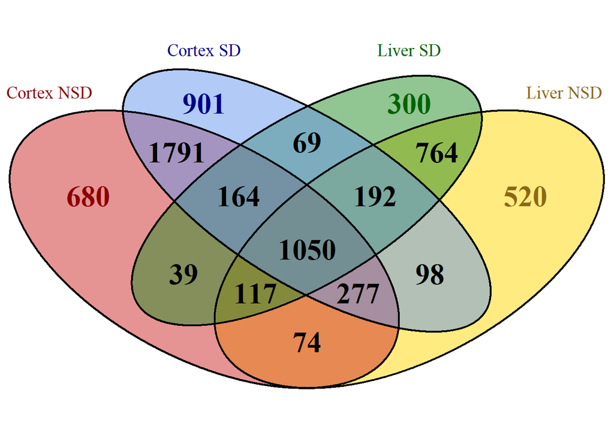

```r
# plot the Venn diagram
v<-draw.quad.venn(area1=a1,area2=a2,area3=a3,area4=a4,
                  n12=n12,n13=n13,n14=n14,n23=n23,n24=n24,n34=n34,
                  n123=n123,n124=n124,n134=n134,n234=n234,
                  n1234=n1234,
                  c("Cortex NSD","Liver NSD","Cortex SD","Liver SD"),
                  fill = c("firebrick3", "gold", "cornflowerblue", "forestgreen"),
                  col = "black", alpha=0.50,
                  label.col = c("darkblue", "black", "darkgreen", "black", "black", "black", "black", "black", "darkred", "black", "black", "black", "black", "goldenrod4", "black"),
                  cex=2, fontfamily = "serif", fontface = "bold",
                  cat.col = c("darkred", "goldenrod4", "darkblue", "darkgreen"),
                  cat.cex=1.2, font=2)
```

Explorate which genes are different between the published and the reproduced results

```r
# original data (=published)
# load files with qvalues of genes for cis-eQTL expression
ceLNSD_published <- read.table("//nas.unil.ch/CIG/GROUPS/FRANKEN/common/PROJECTS/BXD/Analysis/Results/Reproduce_Figure2c/original_data/ciseQTL.Liver.NSD.pvalcorrected.txt",sep='')
ceLSD_published <- read.table("//nas.unil.ch/CIG/GROUPS/FRANKEN/common/PROJECTS/BXD/Analysis/Results/Reproduce_Figure2c/original_data/ciseQTL.Liver.SD.pvalcorrected.txt",sep='')
ceCNSD_published <- read.table("//nas.unil.ch/CIG/GROUPS/FRANKEN/common/PROJECTS/BXD/Analysis/Results/Reproduce_Figure2c/original_data/ciseQTL.Cortex.NSD.pvalcorrected.txt",sep='')
ceCSD_published <- read.table("//nas.unil.ch/CIG/GROUPS/FRANKEN/common/PROJECTS/BXD/Analysis/Results/Reproduce_Figure2c/original_data/ciseQTL.Cortex.SD.pvalcorrected.txt",sep='')

# selects gene names that are at 0.05 or below
ceLNSDnp_published <- rownames(ceLNSD_published)[ceLNSD_published$adjustedpvalue<=0.05]
ceLSDnp_published <- rownames(ceLSD_published)[ceLSD_published$adjustedpvalue<=0.05]
ceCNSDnp_published <- rownames(ceCNSD_published)[ceCNSD_published$adjustedpvalue<=0.05]
ceCSDnp_published <- rownames(ceCSD_published)[ceCSD_published$adjustedpvalue<=0.05]

# newly generated data (=reproduced)
# load files with qvalues of genes for cis-eQTL expression
ceLNSD_reproduced <- read.table("//nas.unil.ch/CIG/GROUPS/FRANKEN/common/PROJECTS/BXD/BXD_mm10/Data/IntermediateLayer/cis-eQTL/ciseQTL.Liver.NSD.pvalcorrected.txt",sep='')
ceLSD_reproduced <- read.table("//nas.unil.ch/CIG/GROUPS/FRANKEN/common/PROJECTS/BXD/BXD_mm10/Data/IntermediateLayer/cis-eQTL/ciseQTL.Liver.SD.pvalcorrected.txt",sep='')
ceCNSD_reproduced <- read.table("//nas.unil.ch/CIG/GROUPS/FRANKEN/common/PROJECTS/BXD/BXD_mm10/Data/IntermediateLayer/cis-eQTL/ciseQTL.Cortex.NSD.pvalcorrected.txt",sep='')
ceCSD_reproduced <- read.table("//nas.unil.ch/CIG/GROUPS/FRANKEN/common/PROJECTS/BXD/BXD_mm10/Data/IntermediateLayer/cis-eQTL/ciseQTL.Cortex.SD.pvalcorrected.txt",sep='')


# selects gene names that are at 0.05 or below
ceLNSDnp_reproduced <- rownames(ceLNSD_reproduced)[ceLNSD_reproduced$adjustedpvalue<=0.05]
ceLSDnp_reproduced <- rownames(ceLSD_reproduced)[ceLSD_reproduced$adjustedpvalue<=0.05]
ceCNSDnp_reproduced <- rownames(ceCNSD_reproduced)[ceCNSD_reproduced$adjustedpvalue<=0.05]
ceCSDnp_reproduced <- rownames(ceCSD_reproduced)[ceCSD_reproduced$adjustedpvalue<=0.05]

# find the differences
# for each category (condition and tissue) individually
for(tissue in c("L","C")){
  for(condition in c("SD","NSD")){
    print(c(tissue,condition))
    print(setdiff(eval(parse(text=paste("ce", tissue, condition, "np_published", sep=""))), eval(parse(text=paste("ce", tissue, condition, "np_reproduced", sep="")))))
    print(setdiff(eval(parse(text=paste("ce", tissue, condition, "np_reproduced", sep=""))), eval(parse(text=paste("ce", tissue, condition, "np_published", sep="")))))
  }
}
```

```
## [1] "L"  "SD"
##   [1] "Sntg1"         "Rrs1"          "2610203C22Rik" "3110035E14Rik"
##   [5] "1700034P13Rik" "Snhg6"         "Ppp1r42"       "Efhc1"
##   [9] "Hs6st1"        "Sema4c"        "Txndc9"        "Col3a1"
##  [13] "Gm20257"       "Map2"          "Vil1"          "Stk36"
##  [17] "Ap1s3"         "Col4a3"        "Ncl"           "Inpp5d"
##  [21] "Ugt1a2"        "Asb1"          "Mterfd2"       "Gm9994"
##  [25] "Ralb"          "Kiss1"         "Zc3h11a"       "Nmnat2"
##  [29] "Rgs8"          "Rnasel"        "Gas5"          "Dnm3"
##  [33] "Gm16548"       "1700009P17Rik" "Mpz"           "Adamts4"
##  [37] "Slamf7"        "Igsf9"         "Slamf8"        "Darc"
##  [41] "Aim2"          "Spta1"         "Grem2"         "Rgs7"
##  [45] "Traf5"         "Gm10516"       "Nudt5"         "Gm13375"
##  [49] "Pnpla7"        "Gpsm1"         "Snhg7"         "Surf6"
##  [53] "D330023K18Rik" "Ncs1"          "Exosc2"        "Crb2"
```

[output cut: 1962 more lines]

```r
# for total unique eQTL
tot_published <- c(ceLNSDnp_published, ceLSDnp_published, ceCNSDnp_published, ceCSDnp_published)
tot_reproduced <- c(ceLNSDnp_reproduced, ceLSDnp_reproduced, ceCNSDnp_reproduced, ceCSDnp_reproduced)

# list of genes interesting to look at
list_genes <- c(setdiff(tot_reproduced, tot_published),setdiff(tot_published, tot_reproduced))
length(list_genes)
```

```
## [1] 3191
```

```r
summary(ceLNSD_published[,"adjustedpvalue"]-ceLNSD_reproduced[rownames(ceLNSD_published),"adjustedpvalue"])
```

```
##    Min. 1st Qu.  Median    Mean 3rd Qu.    Max.    NA's
## -1.0000 -0.0359  0.0019  0.0367  0.0937  0.9980    2364
```

```r
head(ceLNSD_published)
```

```
##         adjustedpvalue     marker
## Sox17     1.574287e-02 rs13471444
## Mrpl15    5.017609e-01  rs6269442
## Lypla1    3.520240e-01 rs13471444
## Tcea1     1.869983e-13 rs31675768
## Atp6v1h   1.737344e-01  rs6269442
## Rb1cc1    1.400594e-01  rs6365999
```

```r
head(ceLNSD_reproduced[rownames(ceLNSD_published),])
```

```
##         adjustedpvalue        marker
## Sox17     0.0593278352    rs30847416
## Mrpl15    0.0035390018    rs31443144
## Lypla1    0.0792134087    rs31443144
## Tcea1     0.0004132031 Affy_10344635
## Atp6v1h   0.0070132914    rs31625087
## Rb1cc1    0.0184067025    rs30658298
```

```r
# calculate ratio of significant associations

length(ceLNSDnp_reproduced)/length(ceLNSD_reproduced$adjustedpvalue)
```

```
## [1] 0.2444849
```

```r
length(ceLSDnp_reproduced)/length(ceLSD_reproduced$adjustedpvalue)
```

```
## [1] 0.213094
```

```r
length(ceCNSDnp_reproduced)/length(ceCNSD_reproduced$adjustedpvalue)
```

```
## [1] 0.2664294
```

```r
length(ceCSDnp_reproduced)/length(ceCSD_reproduced$adjustedpvalue)
```

```
## [1] 0.2886742
```

```r
length(ceLNSDnp_published)/length(ceLNSD_published$adjustedpvalue)
```

```
## [1] 0.2238531
```

```r
length(ceLSDnp_published)/length(ceLSD_published$adjustedpvalue)
```

```
## [1] 0.1879033
```

```r
length(ceCNSDnp_published)/length(ceCNSD_published$adjustedpvalue)
```

```
## [1] 0.3037813
```

```r
length(ceCSDnp_published)/length(ceCSD_published$adjustedpvalue)
```

```
## [1] 0.317617
```

## Differential gene expression

Understand and explain principles used for gene expression.

Reproducing Figure 4c

### Loading data

```r
# loading newly generated datasets
# load table with results of differential expression
DEdata_cortex <- read.table('../../Data/IntermediateLayer/DE/Limma_Cortex.txt', sep="\t")
DEdata_liver <- read.table('../../Data/IntermediateLayer/DE/Limma_Liver.txt', sep="\t")

# loading reference list of 78 genes from (Mongrain, Sleep, 2010)
list_78 <- read.table("../../Data/Exome/78RNA.txt", stringsAsFactors=FALSE)
```

### Functions

```r
# creating a function that plots a volcano plot

volcano_plot <- function(xvariable, yvariable, labels, tissue, dversion, threshold=0.05){
  # process data set

  dataset <- data.frame(x=xvariable, y=yvariable)
  rownames(dataset) <- labels

  # sort the datset by adjusted p-value (lower to higher)
  dataset_sorted <- sort_df(dataset,vars="x")

  # selects transcripts with color
  dataset_sorted$x_selected <- dataset_sorted$x<threshold

  # selects rank of transcripts from 78 genes lists
  list_78_rank <- match(list_78$V1, rownames(dataset_sorted))

  #####################################
  # plotting

  # setting palette
  palette(c("black", "brown2", "dodgerblue4"))

  # plot the graph
  # plot all transcripts in black and significant in red
  plot(1:length(dataset_sorted$x), dataset_sorted$y, pch=20, col=as.factor(dataset_sorted$x_selected),
       main=paste("DE (sd vs nsd) in", tissue), sub=dversion, cex.sub=0.5,
       xlab="", ylab="", ylim=c(-3,3))

  # add transcripts from the 78 list in blue
  points(list_78_rank, dataset_sorted$y[list_78_rank], pch=20, col=3)
}
```

The volcano_plot function has 6 parameters:

- xvariable: DEdata_cortex$adj.P.Val
- yvariable: DEdata_cortex$logFC
- labels: list of gene names (eg: rownames(DEdata_cortex))
- tissue: tissue of the sample (“cortex” or “liver”)
- dversion: version of the dataset used (“newly generated” or “reference”)
- threshold: cutoff for significance of x values (default is 0.05)

### Plotting

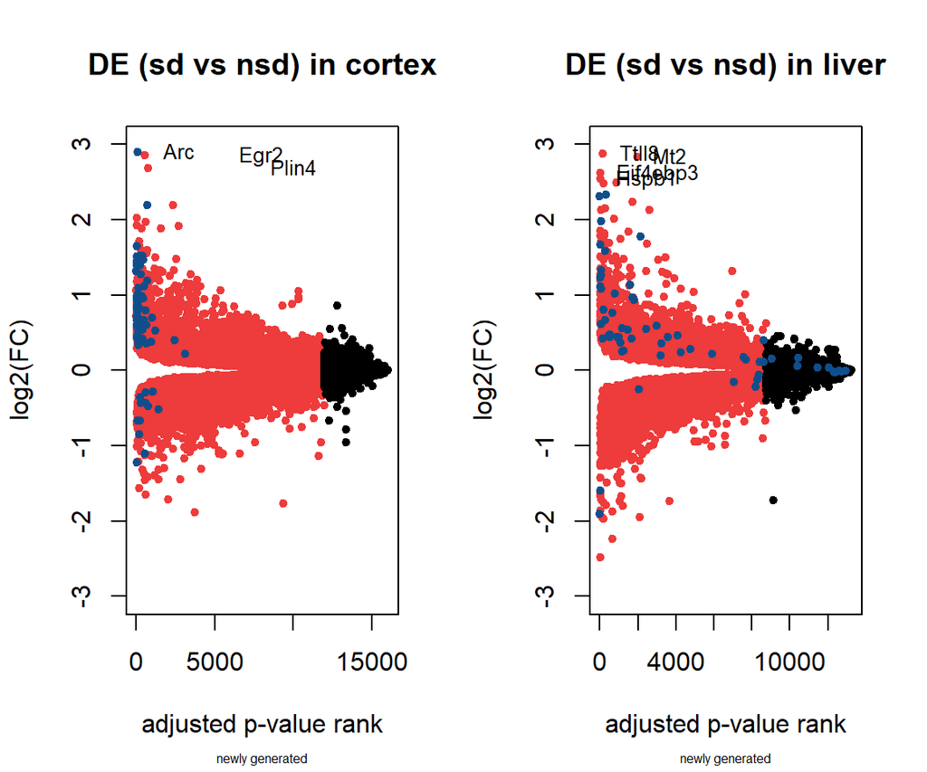

```r
# plot figures

# setting graphical parameters
par(mfrow=c(1,2))

# from newly generated dataset

  # log FC vs adjusted p-value rank

  # cortex
  volcano_plot(xvariable=DEdata_cortex$adj.P.Val, yvariable=DEdata_cortex$logFC, labels=rownames(DEdata_cortex), tissue="cortex", dversion="newly generated", threshold=0.05)
  # add labels for x and y axes
  title(xlab="adjusted p-value rank", ylab="log2(FC)")
  # add top logFc genes labels
  text(x=which(DEdata_cortex$logFC>2.5)*10, y=DEdata_cortex$logFC[DEdata_cortex$logFC>2.5], labels=rownames(DEdata_cortex)[DEdata_cortex$logFC>2.5], pos=4, cex=0.8)
  # liver
  volcano_plot(xvariable=DEdata_liver$adj.P.Val, yvariable=DEdata_liver$logFC, labels=rownames(DEdata_liver), tissue="liver", dversion="newly generated", threshold=0.05)
  # add labels for x and y axes
  title(xlab="adjusted p-value rank", ylab="log2(FC)")
  # add top logFc genes labels
  text(x=which(DEdata_liver$logFC>2.5), y=DEdata_liver$logFC[DEdata_liver$logFC>2.5], labels=rownames(DEdata_liver)[DEdata_liver$logFC>2.5], pos=4, cex=0.8)
```

# Versions